# Homework 2: Sampling and Iteration in the Tidyverse

#### Due 9/25/2020

This homework’s file can also be found on [Github](https://github.com/julia-mccartney/McCartney_Biol_607/blob/master/homework/02_McCartney_Julia_2020.Rmd)

Libraries used

```r
library(palmerpenguins)
library(tidyverse)
library(ggplot2)
library(formattable)
library(reactable)
```

## 1. Some Data with Flippers

### 1a. Load the library palmerpenguins after installing it.

```r
# To install -> install.packages("palmerpenguins")
library(palmerpenguins)
```

### 1b. Show the head of the dataset penguins

```r
#look at the top of the penguins data set
head(penguins)
```

| species | island | bill_length_mm | bill_depth_mm | flipper_length_mm | body_mass_g | sex | year |
| --- | --- | --- | --- | --- | --- | --- | --- |
| Adelie | Torgersen | 39.1 | 18.7 | 181 | 3750 | male | 2007 |
| Adelie | Torgersen | 39.5 | 17.4 | 186 | 3800 | female | 2007 |
| Adelie | Torgersen | 40.3 | 18.0 | 195 | 3250 | female | 2007 |
| Adelie | Torgersen | NA | NA | NA | NA | NA | 2007 |
| Adelie | Torgersen | 36.7 | 19.3 | 193 | 3450 | female | 2007 |
| Adelie | Torgersen | 39.3 | 20.6 | 190 | 3650 | male | 2007 |

### 1c. What do you learn by using str() and summary() on penguins()

```r
#Get a sense of the data in penguins
str(penguins)
## tibble [344 × 8] (S3: tbl_df/tbl/data.frame)
##  $ species          : Factor w/ 3 levels "Adelie","Chinstrap",..: 1 1 1 1 1 1 1 1 1 1 ...
##  $ island           : Factor w/ 3 levels "Biscoe","Dream",..: 3 3 3 3 3 3 3 3 3 3 ...
##  $ bill_length_mm   : num [1:344] 39.1 39.5 40.3 NA 36.7 39.3 38.9 39.2 34.1 42 ...
##  $ bill_depth_mm    : num [1:344] 18.7 17.4 18 NA 19.3 20.6 17.8 19.6 18.1 20.2 ...
##  $ flipper_length_mm: int [1:344] 181 186 195 NA 193 190 181 195 193 190 ...
##  $ body_mass_g      : int [1:344] 3750 3800 3250 NA 3450 3650 3625 4675 3475 4250 ...
##  $ sex              : Factor w/ 2 levels "female","male": 2 1 1 NA 1 2 1 2 NA NA ...
##  $ year             : int [1:344] 2007 2007 2007 2007 2007 2007 2007 2007 2007 2007 ...

summary(penguins)
##       species          island    bill_length_mm  bill_depth_mm
##  Adelie   :152   Biscoe   :168   Min.   :32.10   Min.   :13.10
##  Chinstrap: 68   Dream    :124   1st Qu.:39.23   1st Qu.:15.60
##  Gentoo   :124   Torgersen: 52   Median :44.45   Median :17.30
##                                  Mean   :43.92   Mean   :17.15
##                                  3rd Qu.:48.50   3rd Qu.:18.70
##                                  Max.   :59.60   Max.   :21.50
##                                  NA's   :2       NA's   :2
##  flipper_length_mm  body_mass_g       sex           year
##  Min.   :172.0     Min.   :2700   female:165   Min.   :2007
##  1st Qu.:190.0     1st Qu.:3550   male  :168   1st Qu.:2007
##  Median :197.0     Median :4050   NA's  : 11   Median :2008
##  Mean   :200.9     Mean   :4202                Mean   :2008
##  3rd Qu.:213.0     3rd Qu.:4750                3rd Qu.:2009
##  Max.   :231.0     Max.   :6300                Max.   :2009
##  NA's   :2         NA's   :2
```

From str() and summary() it is apparent that this data is focused on various biometric data (bill length, body mass, etc) of three penguin species (Adelie, Chinstrap, and Gentoo penguins) residing on three islands (Biscoe, Dream, and Torgersen). These observations were taken between 2007 and 2009. (I also learned that I prefer the output given by summary)

### 1d. What are the quantiles of bill depth across the whole data set? What do those quantiles mean?

The quantiles of bill depth (mm) are as follows:

```r
#look at the quantiles for bill depth
quantile(penguins$bill_depth_mm, na.rm = TRUE)
```

```
##   0%  25%  50%  75% 100%
## 13.1 15.6 17.3 18.7 21.5
```

This can also be seen using summary:

```r
# Another way of looking at quantiles
summary(penguins$bill_depth_mm)
```

```
##    Min. 1st Qu.  Median    Mean 3rd Qu.    Max.    NA's
##   13.10   15.60   17.30   17.15   18.70   21.50       2
```

## 2. What’s here? Let’s use dplyr!

### 2a. If I have a vector, c(1,4,7,NA,9), what is its mean?

Note, the NA is going to cause a problem. Look at ?mean to learn how to solve it.

```r
# Create vector
my_vector <- c(1,4,7,NA,9)

mean(my_vector)
```

```
## [1] NA
```

Because there is an NA present, R cannot compute the mean - the program ‘knows’ that, without knowing the 4th value, it cannot know the mean of the entire vector.

This can be solved with `na.rm`, which removes NAs from the vector before calculating the mean. This way, it will be as if the code was `mean(c(1,4,7,9))`

```r
# Remove NAs in vector
mean(my_vector, na.rm = TRUE)
```

```
## [1] 5.25
```

### 2b. What is the mean, sd, and median of body mass across the data set?

Note, these NAs are going to cause some problems, so you might need to look at the documentation for the relevant functions.

```r
# Calculate mean, median, and sd for body mass
penguins %>%
 summarize(Mean_Body_Mass = mean(body_mass_g, na.rm = TRUE), # calculate mean
            Median_Body_Mass = median(body_mass_g, na.rm = TRUE), # calculate median
            Standard_Deviation_Body_Mass = sd(body_mass_g, na.rm = TRUE)) %>% # calculate sd
  formattable() # make it look a bit nicer
```

| Mean_Body_Mass | Median_Body_Mass | Standard_Deviation_Body_Mass |
| --- | --- | --- |
| 4201.754 | 4050 | 801.9545 |

### 2c. Repeat 2b, but, show us how these quantities differ by species

```r
# Calculate mean, median, and sd for body mass by species
penguins %>%
  group_by(species) %>% # aggregate data by species
  summarize(Mean_Body_Mass = mean(body_mass_g, na.rm = TRUE), # calculate mean
            Median_Body_Mass = median(body_mass_g, na.rm = TRUE), # calculate median
            Standard_Deviation_Body_Mass = sd(body_mass_g, na.rm = TRUE)) %>% # calculate sd
  formattable()
```

| species | Mean_Body_Mass | Median_Body_Mass | Standard_Deviation_Body_Mass |
| --- | --- | --- | --- |
| Adelie | 3700.662 | 3700 | 458.5661 |
| Chinstrap | 3733.088 | 3700 | 384.3351 |
| Gentoo | 5076.016 | 5000 | 504.1162 |

### 2d. Repeat 2c, but just for Biscoe island. What is different in the results?

```r
# Calculate mean, median, and sd for body mass by species for Biscoe island
penguins %>%
  filter(island == "Biscoe") %>% # select only samples from Biscoe island
  group_by(species) %>% # aggregate data by species
  summarize(Mean_Body_Mass = mean(body_mass_g, na.rm = TRUE), # calculate mean
            Median_Body_Mass = median(body_mass_g, na.rm = TRUE), # calculate median
            Standard_Deviation_Body_Mass = sd(body_mass_g, na.rm = TRUE)) %>% # calculate sd
  formattable() # make it look a little nicer
```

| species | Mean_Body_Mass | Median_Body_Mass | Standard_Deviation_Body_Mass |
| --- | --- | --- | --- |
| Adelie | 3709.659 | 3750 | 487.7337 |
| Gentoo | 5076.016 | 5000 | 504.1162 |

Only two species are represented on Biscoe island - Adelie and Gentoo penguins. The mean and median body mass for each species are slightly higher for Adelie penguins and exactly the same for Gentoo penguins on Biscoe island as they are across all islands. (Looking at the data, we can see that all of the Gentoo penguins sampled are on Biscoe island)

```r
# look at the number of Gentoo penguins by island
penguins %>%
  filter(species == "Gentoo") %>% # pull only Gentoo samples
  select(species, island) %>% # look at the number of samples per island
  summary()  # view
```

```
##       species          island
##  Adelie   :  0   Biscoe   :124
##  Chinstrap:  0   Dream    :  0
##  Gentoo   :124   Torgersen:  0
```

### 2e. Make a species-island column in penguins using paste().

This is an awesome function that takes multiple strings, and slams them together using the argument sep = to define how the string should be combined. Try out paste(“Hello”, “Goodbye”, sep = “!”) to see how it works. Have the two be separated by _.

```r
# Create a column for species and island
penguins <- penguins %>%
  na.omit() %>%
  mutate(species_island = paste(species, island, sep = "_")) # Merge species and island, but separate only with a "_"
penguins %>%
   head() %>% # check
  formattable() # make it look nicer
```

| species | island | bill_length_mm | bill_depth_mm | flipper_length_mm | body_mass_g | sex | year | species_island |
| --- | --- | --- | --- | --- | --- | --- | --- | --- |
| Adelie | Torgersen | 39.1 | 18.7 | 181 | 3750 | male | 2007 | Adelie_Torgersen |
| Adelie | Torgersen | 39.5 | 17.4 | 186 | 3800 | female | 2007 | Adelie_Torgersen |
| Adelie | Torgersen | 40.3 | 18.0 | 195 | 3250 | female | 2007 | Adelie_Torgersen |
| Adelie | Torgersen | 36.7 | 19.3 | 193 | 3450 | female | 2007 | Adelie_Torgersen |
| Adelie | Torgersen | 39.3 | 20.6 | 190 | 3650 | male | 2007 | Adelie_Torgersen |
| Adelie | Torgersen | 38.9 | 17.8 | 181 | 3625 | female | 2007 | Adelie_Torgersen |

## 3. A Little Light Plotting

### 3a. Show the distribution of flipper_length_mm by species and island using boxplots.

For one point of extra credit, redo creating the species_island column with the sep as `\n` instead of _. What does do? You will find it very handy in the future.

The string `\n` is used to indicate a new line

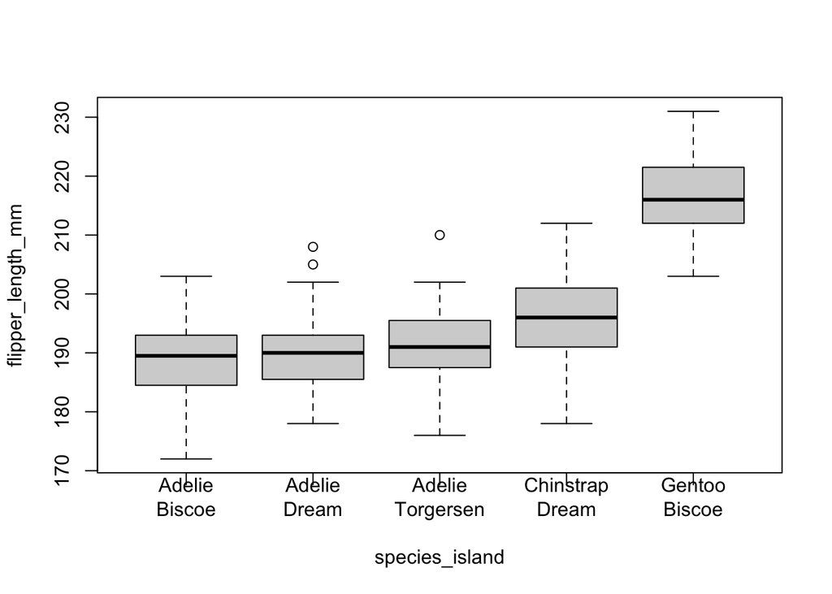

```r
# Plot flipper length by species and island

penguins <- penguins %>%
  mutate(species_island = paste(species, island, sep = "\n")) # change separation

# Plot
boxplot(flipper_length_mm ~ species_island, data = penguins)
```

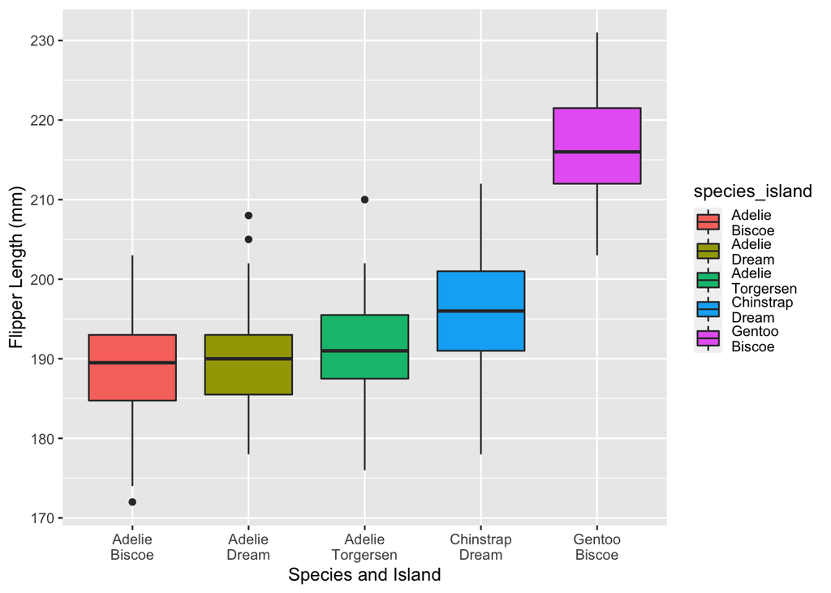

```r
# Same plot but ggplot is just better
ggplot(penguins, aes(x = species_island, y = flipper_length_mm, fill = species_island))+
  geom_boxplot()+
  labs(x = "Species and Island",
       y = "Flipper Length (mm)")
```

### 3b. Show the relationship between average flipper length and average body mass by species and island. What do you see?

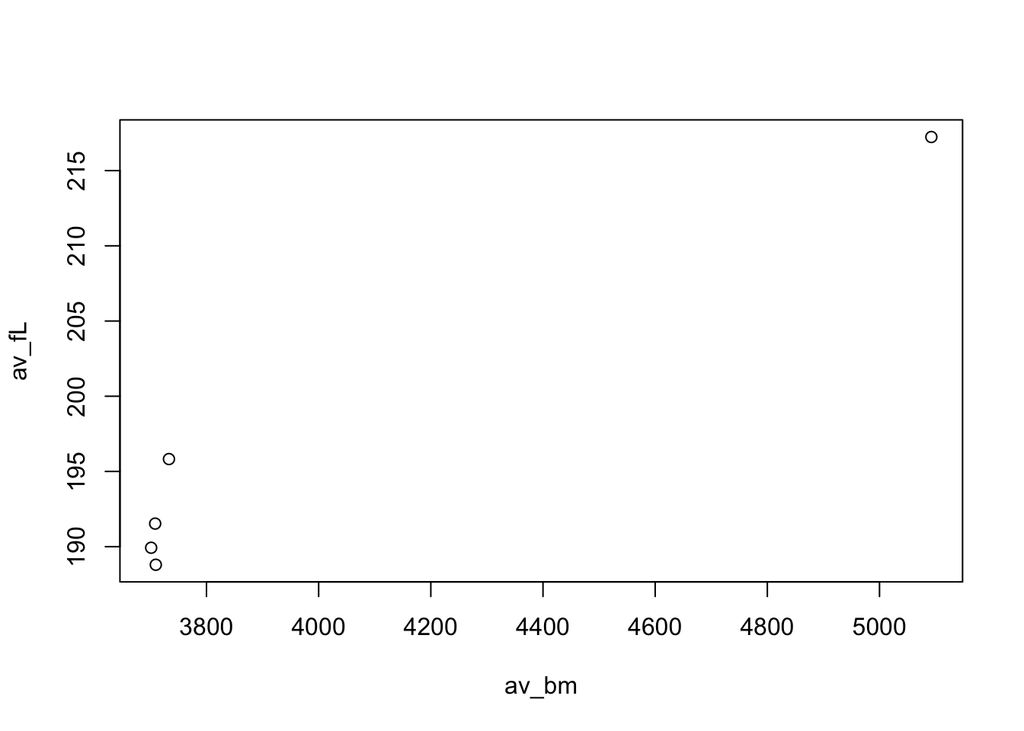

```r
# Plot av  body mass by flipper length, group by island/species
penguins %>%
  group_by(species_island) %>% # aggregate by species and island
  summarize(av_fL = mean(flipper_length_mm, na.rm = TRUE), # calculate the mean flipper length
            av_bm = mean(body_mass_g, na.rm = TRUE)) %>%  # calculate the mean body mass
  plot(av_fL ~ av_bm, data = .)
```

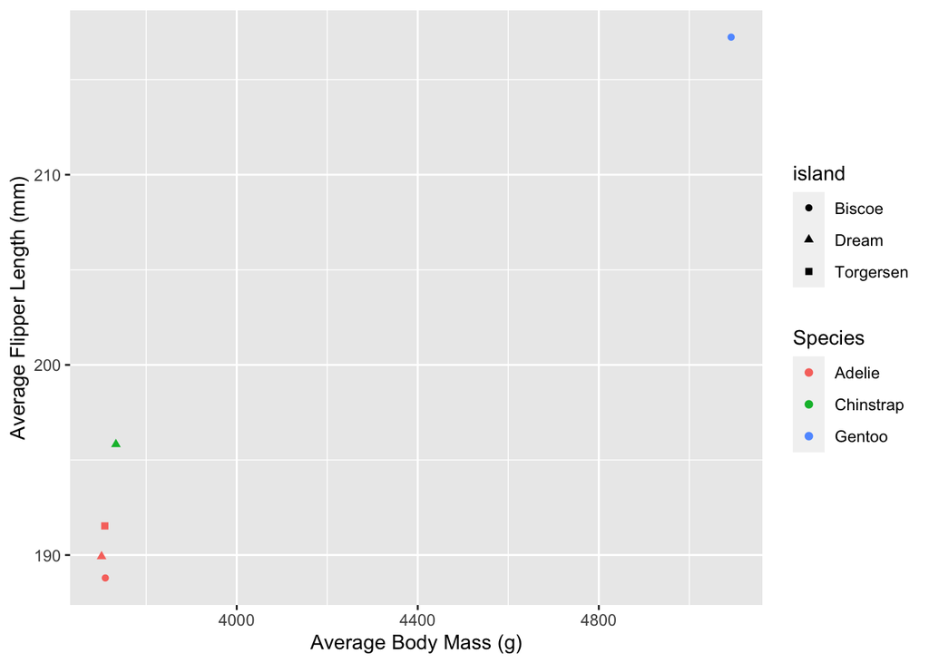

```r
# Better in ggplot
penguins %>%
  group_by(species, island) %>% # aggregate data by species/island
  summarize(av_fL = mean(flipper_length_mm, na.rm = TRUE), # calculate mean flipper length
            av_bm = mean(body_mass_g, na.rm = TRUE)) %>%  # calculate mean body mass
ggplot(aes(y= av_fL, x = av_bm, color = species, shape = island)) + # plot
  geom_point(na.rm = TRUE) +
  labs(x = "Average Body Mass (g)",
       y = "Average Flipper Length (mm)",
       color = "Species")
```

There seems like there may be a connection between body mass (g) and flipper length (mm), but there are clearly differences in the data between species and across islands.

### 3c. Interesting. What if you had made the same plot with the whole dataset? What do you see? Is there anything that could clarify the result any more? Think about it - lots of possible right answers here.

If we look at the spread of these two metrics for the whole dataset…

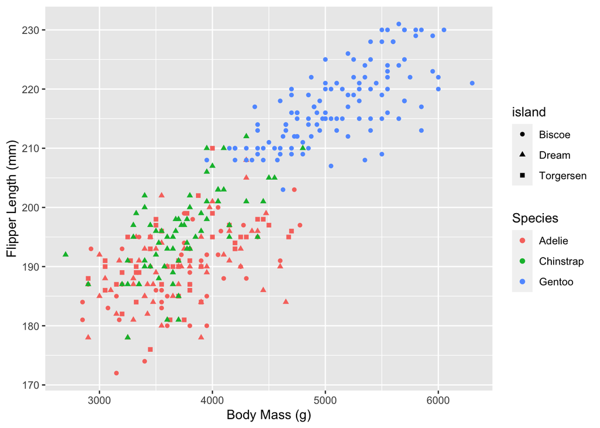

```r
#

penguins %>%
  group_by(species, island) %>% # aggregate data by species/island
ggplot(aes(y= flipper_length_mm, x = body_mass_g, color = species, shape = island)) + # plot
  geom_point(na.rm = TRUE) +
  labs(x = "Body Mass (g)",
       y = "Flipper Length (mm)",
       color = "Species")
```

Not only do we see a distinct separation between the Gentoo penguins and the Adelie and Chinstrap penguins in *both* flipper length and body mass, but also that the species are not well distributed across islands. In fact:

| Island | Species | Total Number Sampled |
| --- | --- | --- |
| Biscoe | Adelie | 44 |
| Biscoe | Gentoo | 119 |
| Dream | Adelie | 55 |
| Dream | Chinstrap | 68 |
| Torgersen | Adelie | 47 |

Not every species is seen at each island! If we look at the graph of the averages again, this becomes even more clear

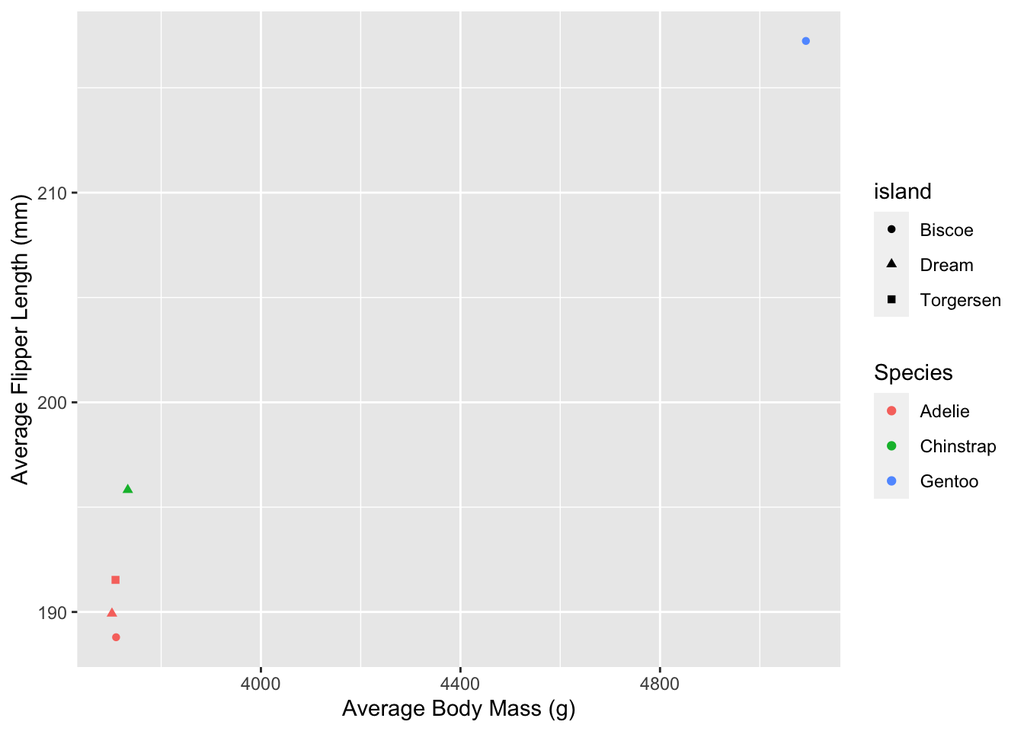

```r
# same plot as above
penguins %>%
  group_by(species, island) %>% # aggregate data by species/island
  summarize(av_fL = mean(flipper_length_mm, na.rm = TRUE), # calculate mean flipper length
            av_bm = mean(body_mass_g, na.rm = TRUE)) %>%  # calculate mean body mass
ggplot(aes(y= av_fL, x = av_bm, color = species, shape = island)) + # plot
  geom_point(na.rm = TRUE) +
  labs(x = "Average Body Mass (g)",
       y = "Average Flipper Length (mm)",
       color = "Species")
```

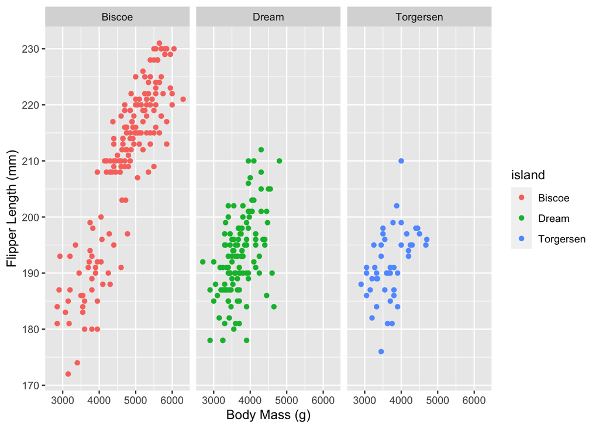

…and then look at the relationship of the averages.

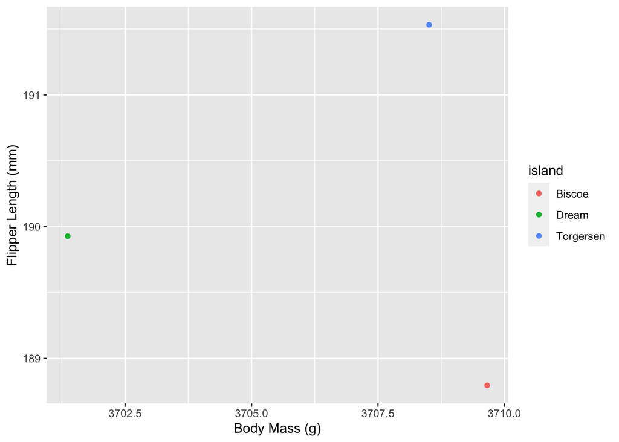

```r
penguins %>%
  group_by(island) %>%
  filter(species == "Adelie") %>%
  summarize(av_fL = mean(flipper_length_mm, na.rm = TRUE),
            av_bm = mean(body_mass_g, na.rm = TRUE)) %>%
ggplot(aes(y= av_fL, x = av_bm, color = island)) +
  geom_point(na.rm = TRUE) +
  labs(y = "Flipper Length (mm)",
       x = "Body Mass (g)"
  )
```

After all of that, what do we know? There is apparently a relationship between flipper length and body mass - as one increases, so does the other, and the exact nature of that relationship (the slope if we were to run a linear regression), seems like it would be the same across species. However, the averages of each of theses groups varies depending on species and island, and graphing just these metrics obscures the pattern seen in the raw data. A linear regression would likely be more useful in understanding this part of the data than averages.

## 4. Let’s get ready to simulate

### 4a. Grab the values for bill_length_mm for Gentoo penguins in Biscoe Island and put it into an object.

Note, the dplyr function pull() is kinda cool, as if you apply it to a data frame, it will pull out a vector from a column of interest. Try 21, 21, 22.8, 21.4, 18.7, 18.1, 14.3, 24.4, 22.8, 19.2, 17.8, 16.4, 17.3, 15.2, 10.4, 10.4, 14.7, 32.4, 30.4, 33.9, 21.5, 15.5, 15.2, 13.3, 19.2, 27.3, 26, 30.4, 15.8, 19.7, 15, 21.4. Kinda cool. Might help you here.

```r
bl_gentoo_bis <- penguins %>%
  na.omit() %>% # remove NAs
  filter(species == "Gentoo",# only Gentoo penguins
         island == "Biscoe") %>% # only penguins on Biscoe island
  pull(bill_length_mm) # pull out the bill_length_mm column

head(bl_gentoo_bis) # view
```

```
## [1] 46.1 50.0 48.7 50.0 47.6 46.5
```

### 4b. Use replicate() to calculate the standard error of the mean 10 times.

Use a formula! Don’t forget that NA values shouldn’t be included!

NAs were removed in the previous step.

```r
replicate(n=10, # replicate 10 times
          sd(bl_gentoo_bis)/sqrt(length(bl_gentoo_bis))) # calculate SEM
```

```
##  [1] 0.2847372 0.2847372 0.2847372 0.2847372 0.2847372 0.2847372 0.2847372
##  [8] 0.2847372 0.2847372 0.2847372
```

### 4c. Use map_df() to create a data frame with the mean and sd of different sample sizes using the first 5 through 100 values (so, n = 5:100 - smallest sample size will have the values 1-5).

Make sure the sample size is included in the final data frame.

```r
# making a df with subsamples
subsampled_gentoo_bl <- map_df(5:100, # for numbers 5-100
                               ~data.frame( # create a dataframe
  sample_size = .x, # column with sample size
  mean = mean(bl_gentoo_bis[1:.x]), # calculatte mean
  sd = sd(bl_gentoo_bis[1:.x]) # calculate sd
))

head(subsampled_gentoo_bl) # view
```

```
##   sample_size     mean       sd
## 1           5 48.48000 1.666433
## 2           6 48.15000 1.695582
## 3           7 47.75714 1.864454
## 4           8 47.62500 1.766150
## 5           9 47.14444 2.192665
## 6          10 47.11000 2.070132
```

### 4d. Plot the relationship between sample size and SD and sample size versus SE of the mean. What difference do you see and why?

Note, you’ll need to create a column for SE here!

+2 EC for using par() to make a two-panel plot. Don’t forget to reset back to a single plot per panel after making a two-panel plot. Otherwise things get weird.

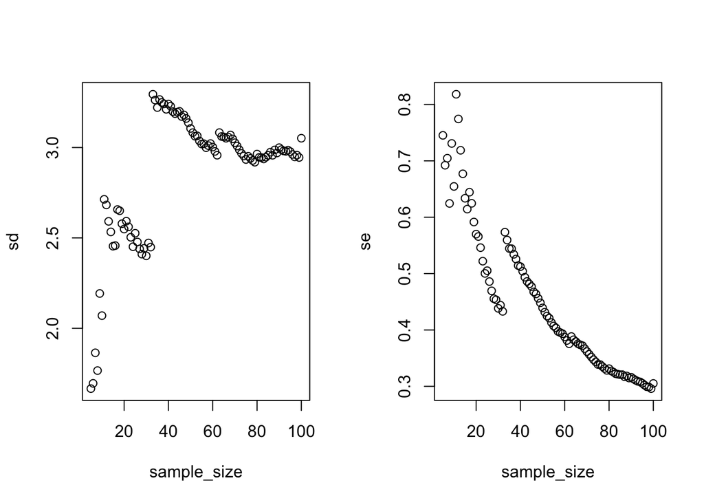

```r
# Calculate SE
subsampled_gentoo_bl <- subsampled_gentoo_bl %>%
  mutate(se = sd/sqrt(sample_size)) # calculate SE

# plot sd and se over sample size - two-panel plot
par(mfrow=c(1,2))
plot(sd ~ sample_size, data = subsampled_gentoo_bl)
plot(se ~ sample_size, data = subsampled_gentoo_bl)
```

```r
par(mfrow=c(1,1))
```

We see an increase in standard deviation (to an extent) as sample size increases, though this is by no means linear, and a decrease in standard error of the mean as the sample size increases (a much more linear relationship). This occurs because, as our sample size increases, we have more values to calculate the standard deviation. The standard deviation is a measure of overall variability. As we increase our sample size, we increase potential values we can have included in our draw, which increases variability. However, as some point we get the majority of the spread included (peak sd) - increasing sample size decreases variability because the majority of the added values will continue to fall within that range (essentially, the sum of the differences of the mean will increase more slowly than the sample size, leading to a smaller number)

Standard error of the mean decreases with sample size as it is a measure of precision and increases as we include more data. The more samples we take, the more sure we can be that the overall dataset is representative of the population (it is much more likely to get 5 outliers than 100 outliers!).

## Extra Credit

Making beautiful tables is hard. There are a number of good packages to help you do that - and they were recently featured in this [excellent article.](https://rfortherestofus.com/2019/11/how-to-make-beautiful-tables-in-r/) Make a beautiful table showing the average properties of bills of penguins by species, sex, and island. Use whatever package you like. A basic nice table is worth 4 points. +1 for every additional bit of information you can convey with the table other than a nicely formatted table. Please explain what you have done to get each point. +1 for naturally incorporating each additional piece of information about properties beyond means. How visually appealing can you make this?

```r
# We want to create a table including the average properties of bills of penguins by species, sex, and island.

# Remove NAs
penguins <- penguins %>%
  na.omit()

# Get a count of the total number of penguins that fall into species-sex-island groups
penguins_summary_count <- penguins %>%
  group_by(species, sex, island) %>%
   count(name = "Count")

# Calculate summary statistics for penguin biometrics
penguins_summary <- penguins %>%
  group_by(species, sex, island) %>%  # aggregate data by species, sex, island
  summarize(mean_bill_L = mean(bill_length_mm), # calculate mean bill length
          mean_bill_D = mean(bill_depth_mm), # calculate bill depth
          sd_bill_L = sd(bill_length_mm), # calculate sd bill length
          sd_bill_D = sd(bill_depth_mm)) %>%  # calculate sd bill depth
  merge(.,penguins_summary_count, by = c("species", "island", "sex"))
```

I plan to use the package [formattable](https://www.rdocumentation.org/packages/formattable/versions/0.2.0.1) to create my table. However, I want the table to be as clean as possible - I don’t want to see the species or island listed multiple times in a row. When searching how to do this, I came across [this solution](https://stackoverflow.com/questions/51450402/how-to-collapse-groups-of-row-values-within-a-table-using-formattable). Writing functions are beyond me right now. **I am in no way trying to take credit for it,** but will gladly use it!

```r
# from https://stackoverflow.com/questions/51450402/how-to-collapse-groups-of-row-values-within-a-table-using-formattable

collapse_rows_df <- function(df, variable){

  group_var <- enquo(variable)

  df %>%
    group_by(!! group_var) %>%
    mutate(groupRow = 1:n()) %>%
    ungroup() %>%
    mutate(!!quo_name(group_var) := ifelse(groupRow == 1, as.character(!! group_var), "")) %>%
    select(-c(groupRow))
}
```

And now we can put together the table!

```r
# Put together at table
options(digits = 3)

# setting up colors in table
color_set <- formatter("span",
  style = x ~ style(color = ifelse(x < 1, "green",
    ifelse(x < 2, "red", "darkred"))))


penguins_summary %>%
  relocate(sd_bill_L, .after=mean_bill_L) %>%
    rename(Species = species,
         Island = island,
         Sex = sex,
        Mean_Bill_Depth_mm = mean_bill_D,
        Mean_Bill_Length_mm = mean_bill_L,
        Standard_Deviation_of_Bill_Length = sd_bill_L,
        Standard_Deviation_of_Bill_Depth = sd_bill_D) %>%
  collapse_rows_df(Species) %>% # thank you Michael Harper!
formattable(list(Count = color_tile("white", "lightblue"), # show sampling  size through color intensity
                 sex = color_tile("pink", "lightblue"), # color code sex
                Standard_Deviation_of_Bill_Length = color_set, # color code SD
                Standard_Deviation_of_Bill_Depth = color_set
                 ))
```

| Species | Island | Sex | Mean_Bill_Length_mm | Standard_Deviation_of_Bill_Length | Mean_Bill_Depth_mm | Standard_Deviation_of_Bill_Depth | Count |
| --- | --- | --- | --- | --- | --- | --- | --- |
| Adelie | Biscoe | female | 37.4 | 1.76 | 17.7 | 1.091 | 22 |
|  | Biscoe | male | 40.6 | 2.01 | 19.0 | 0.880 | 22 |
|  | Dream | female | 36.9 | 2.09 | 17.6 | 0.897 | 27 |
|  | Dream | male | 40.1 | 1.75 | 18.8 | 1.033 | 28 |
|  | Torgersen | female | 37.6 | 2.21 | 17.6 | 0.880 | 24 |
|  | Torgersen | male | 40.6 | 3.03 | 19.4 | 1.082 | 23 |
| Chinstrap | Dream | female | 46.6 | 3.11 | 17.6 | 0.781 | 34 |
|  | Dream | male | 51.1 | 1.56 | 19.3 | 0.761 | 34 |
| Gentoo | Biscoe | female | 45.6 | 2.05 | 14.2 | 0.540 | 58 |
|  | Biscoe | male | 49.5 | 2.72 | 15.7 | 0.741 | 61 |